# User-defined MCMC samplers

## NIMBLE training materials module

Nimble Development Team

# Introduction

Nimble's MCMC system was designed to be extensible - it's easy for users to add samplers and use them right away for their models.

Let's start with a very basic example that slightly extends Nimble's built-in Metropolis sampler.

# The reflection sampler

Suppose you have a parameter with a finite domain, in particular a fixed lower bound, such as a gamma distribution, a uniform distribution, or a lognormal distribution.

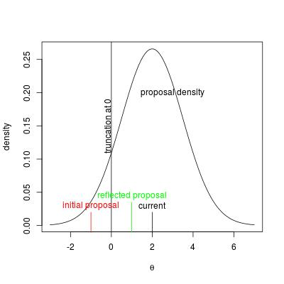

# Nimble's Metropolis sampler

Coding this sampler would be easy from scratch and is even easier if we simply make very small changes to the existing Nimble Metropolis sampler.

Let's look at the code for the Metropolis sampler. You can find this in the file *R/MCMC_samplers.R* in the source code for the Nimble package (note that `nimble:::sampler_RW` is not useful to look at, as it shows a modified version of this -- the nimbleFunction after it has been built).

```r
sampler_RW <- nimbleFunction(
    contains = sampler_BASE,
    setup = function(model, mvSaved, target, control) {
        ###  control list extraction  ###
        adaptive      <- control$adaptive
        adaptInterval <- control$adaptInterval
        scale         <- control$scale
        ###  node list generation  ###
        targetAsScalar <- model$expandNodeNames(target,
                       returnScalarComponents = TRUE)
        if(length(targetAsScalar) > 1)
                        stop('more than one target; cannot use RW sampler, try RW_block sampler')
        calcNodes  <- model$getDependencies(target)
        ###  numeric value generation  ###
        scaleOriginal <- scale
        timesRan      <- 0
        timesAccepted <- 0
        timesAdapted  <- 0
        scaleHistory          <- c(0, 0)
        acceptanceRateHistory <- c(0, 0)
        ## variables previously inside of nested functions:
        optimalAR <- 0.44
        gamma1    <- 0
    },

    run = function() {
        propValue <- rnorm(1, mean = model[[target]], sd = scale)
        model[[target]] <<- propValue
        logMHR <- calculateDiff(model, calcNodes)
        jump <- decide(logMHR)
        if(jump)
            nimCopy(from = model, to = mvSaved, row = 1, nodes = calcNodes,
                         logProb = TRUE)
        else
            nimCopy(from = mvSaved, to = model, row = 1, nodes = calcNodes,
                         logProb = TRUE)
        if(adaptive)     adaptiveProcedure(jump)
    },

    methods = list(

        adaptiveProcedure = function(jump = logical()) {
            timesRan <<- timesRan + 1
            if(jump)     timesAccepted <<- timesAccepted + 1
            if(timesRan %% adaptInterval == 0) {
                acceptanceRate <- timesAccepted / timesRan
                timesAdapted <<- timesAdapted + 1
                setSize(scaleHistory,          timesAdapted)
                setSize(acceptanceRateHistory, timesAdapted)
                scaleHistory[timesAdapted] <<- scale
                acceptanceRateHistory[timesAdapted] <<- acceptanceRate
                gamma1 <<- 1/((timesAdapted + 3)^0.8)
                gamma2 <- 10 * gamma1
                adaptFactor <- exp(gamma2 * (acceptanceRate - optimalAR))
                scale <<- scale * adaptFactor
                timesRan <<- 0
                timesAccepted <<- 0
            }
        },

        reset = function() {
            scale <<- scaleOriginal
            timesRan      <<- 0
            timesAccepted <<- 0
            timesAdapted  <<- 0
            scaleHistory          <<- scaleHistory          * 0
            acceptanceRateHistory <<- acceptanceRateHistory * 0
            gamma1 <<- 0
        }
    ), where = getLoadingNamespace()
)
```

Much of that code has to do with making the sampler adaptive, so that the proposal scale adapts so that a good acceptance rate is achieved.

# Modifying the *setup* function

The *run* function for the reflection sampler needs to check the proposed value against the distribution bounds and modify the proposal as needed.

However, we first need to modify the *setup* function to check if the distribution has finite lower or upper bounds and only consider scalar parameters, thereby avoiding some computation at run-time.

```r
    setup = function(model, mvSaved, target, control) {
        ###  control list extraction  ###
        adaptive      <- control$adaptive
        adaptInterval <- control$adaptInterval
        scale         <- control$scale
        ###  node list generation  ###
        targetAsScalar <- model$expandNodeNames(target, returnScalarComponents = TRUE)
        if(length(targetAsScalar) > 1)     stop('more than one target; cannot use RW sampler, try RW_block sampler')

        ################# ADDED code #############################
        dist <- model$getNodeDistribution(target)
        scalar <- getDistribution(dist)$types$value$nDim == 0
        if(scalar)
                rg <- getDistribution(dist)$range
        if(scalar && (rg[1] > -Inf || rg[2] < Inf))
                  reflect <- TRUE else reflect <- FALSE
        ##########################################################

        calcNodes  <- model$getDependencies(target)
        ###  numeric value generation  ###
        scaleOriginal <- scale
        timesRan      <- 0
        timesAccepted <- 0
        timesAdapted  <- 0
        scaleHistory          <- c(0, 0)
        acceptanceRateHistory <- c(0, 0)
        ## variables previously inside of nested functions:
        optimalAR <- 0.44
        gamma1    <- 0
    }
```

# Modifying the *run* function

```r
    run = function() {
        propValue <- rnorm(1, mean = model[[target]], sd = scale)

        #################### ADDED code #############################
        if(reflect) {
             while(propValue < rg[1] | propValue > rg[2]) {
                   if(propValue < rg[1]) propValue <- 2*rg[1] - propValue
                   if(propValue > rg[2]) propValue <- 2*rg[2] - propValue
             }
        }
        #############################################################

        model[[target]] <<- propValue
        logMHR <- calculateDiff(model, calcNodes)
        jump <- decide(logMHR)
        if(jump)
            nimCopy(from = model, to = mvSaved, row = 1, nodes = calcNodes,
                         logProb = TRUE)
        else
            nimCopy(from = mvSaved, to = model, row = 1, nodes = calcNodes,
                         logProb = TRUE)
        if(adaptive)     adaptiveProcedure(jump)
    }
```

# Comments

1. This implementation doesn't account for bounds induced by user-defined truncation of a node in a model nor the bounds defined by the parameters of a uniform distribution. That would require more diving into Nimble's internal plumbing, though in the future more information on the bounds of a node at run-time should be available.
2. We used some functionality that may not be fully explained in Nimble's documentation. For this sort of thing, you can always ask a question in the Nimble user Google group.

# The full sampler function

We also need to change the name of the function.

```r
sampler_RW_reflect <- nimbleFunction(
    contains = sampler_BASE,
    setup = function(model, mvSaved, target, control) {
        ###  control list extraction  ###
        adaptive      <- control$adaptive
        adaptInterval <- control$adaptInterval
        scale         <- control$scale
        ###  node list generation  ###
        targetAsScalar <- model$expandNodeNames(target,
                       returnScalarComponents = TRUE)
        if(length(targetAsScalar) > 1)
                       stop('more than one target; cannot use RW sampler, try RW_block sampler')

        ### ADDED code
        dist <- model$getNodeDistribution(target)
        scalar <- getDistribution(dist)$types$value$nDim == 0
        if(scalar)
                rg <- getDistribution(dist)$range
        if(scalar && (rg[1] > -Inf || rg[2] < Inf))
                  reflect <- TRUE else reflect <- FALSE
        ###

        calcNodes  <- model$getDependencies(target)
        ###  numeric value generation  ###
        scaleOriginal <- scale
        timesRan      <- 0
        timesAccepted <- 0
        timesAdapted  <- 0
        scaleHistory          <- c(0, 0)
        acceptanceRateHistory <- c(0, 0)
        ## variables previously inside of nested functions:
        optimalAR <- 0.44
        gamma1    <- 0
    },

    run = function() {
        propValue <- rnorm(1, mean = model[[target]], sd = scale)
        if(reflect) {
             if(propValue < rg[1]) propValue <- 2*rg[1] - propValue
             if(propValue > rg[2]) propValue <- 2*rg[2] - propValue
        }
        model[[target]] <<- propValue
        logMHR <- calculateDiff(model, calcNodes)
        jump <- decide(logMHR)
        if(jump)
            nimCopy(from = model, to = mvSaved, row = 1, nodes = calcNodes,
                         logProb = TRUE)
        else
            nimCopy(from = mvSaved, to = model, row = 1, nodes = calcNodes,
                         logProb = TRUE)
        if(adaptive)     adaptiveProcedure(jump)
    },

    methods = list(

        adaptiveProcedure = function(jump = logical()) {
            timesRan <<- timesRan + 1
            if(jump)     timesAccepted <<- timesAccepted + 1
            if(timesRan %% adaptInterval == 0) {
                acceptanceRate <- timesAccepted / timesRan
                timesAdapted <<- timesAdapted + 1
                setSize(scaleHistory,          timesAdapted)
                setSize(acceptanceRateHistory, timesAdapted)
                scaleHistory[timesAdapted] <<- scale
                acceptanceRateHistory[timesAdapted] <<- acceptanceRate
                gamma1 <<- 1/((timesAdapted + 3)^0.8)
                gamma2 <- 10 * gamma1
                adaptFactor <- exp(gamma2 * (acceptanceRate - optimalAR))
                scale <<- scale * adaptFactor
                timesRan <<- 0
                timesAccepted <<- 0
            }
        },

        reset = function() {
            scale <<- scaleOriginal
            timesRan      <<- 0
            timesAccepted <<- 0
            timesAdapted  <<- 0
            scaleHistory          <<- scaleHistory          * 0
            acceptanceRateHistory <<- acceptanceRateHistory * 0
            gamma1 <<- 0
        }
    ), where = getLoadingNamespace()
)
```

# Using the sampler

Using the sampler is simple. Just modify the default MCMC configuration for a model to use the new sampler on a node of interest.

Let's try this with the *blocker* model, which is a random effects meta-analysis of clinical trial data.

In this case, we could use a conjugate sampler, which would automatically respect the lower bound of zero, but for illustration let's compare a standard Metropolis sampler with the new reflection sampler.

```r
model <- readBUGSmodel('blocker', dir = system.file('classic-bugs','vol1','blocker', package = 'nimble'))
```

```
## defining model...
```

```
## Detected rc,rt as data within 'constants'.
## Adding rc,rt as data for building model.
```

```
## building model...
## setting data and initial values...
## checking model...   (use nimbleModel(..., check = FALSE) to skip model check)
## model building finished
```

```r
model$tau
```

```
## [1] 1
```

```r
model$tau <- 0.01
conf <- configureMCMC(model)
conf$removeSamplers('tau')
# as baseline, use standard Metropolis for tau
conf$addSampler('tau', type = 'RW')
```

```
## [47] RW sampler: tau,  adaptive: TRUE,  adaptInterval: 200,  scale: 1
```

```r
mcmc <- buildMCMC(conf)
niter <- 10000
cmodel <- compileNimble(model)
cmcmc <- compileNimble(mcmc, project = model)
set.seed(0)
cmcmc$run(niter)
```

```r
smp1 <- as.matrix(cmcmc$mvSamples)
```

Now we'll try the reflection sampler instead.

```r
conf$removeSamplers('tau')
# for comparison, consider the reflection sampler
conf$addSampler('tau', type = 'RW_reflect')
```

```
## [47] RW_reflect sampler: tau,  adaptive: TRUE,  adaptInterval: 200,  scale: 1
```

```r
mcmc <- buildMCMC(conf)
cmcmc <- compileNimble(mcmc, project = model, resetFunctions = TRUE)

nimCopy(model, cmodel)
set.seed(0)
cmcmc$run(niter)
```

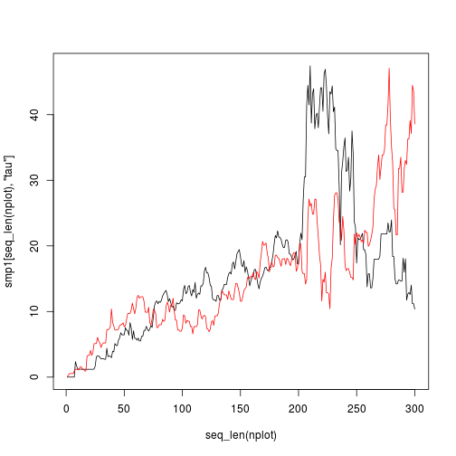

```r
smp2 <- as.matrix(cmcmc$mvSamples)

nplot <- 300
plot(seq_len(nplot), smp1[seq_len(nplot), 'tau'], type = 'l')
lines(seq_len(nplot), smp2[seq_len(nplot), 'tau'], col = 'red')
```

```r
library(coda, quietly = TRUE)
effectiveSize(smp1[ , 'tau'])
```

```
##     var1
## 29.98127
```

```r
effectiveSize(smp2[ , 'tau'])
```

```
##     var1
## 71.73441
```

Side note: the random effects variance component in this model is given a gamma prior on the precision scale, but best practices for random effects variance components, including a strong argument against the gamma/inverse-gamma prior, can be found in Gelman (2006, Bayesian Analysis 1:515-534).

# Exercises